# R4_Internal_Lab_Clustering

### The data set has information about features of silhouette extracted from the images of different cars

Four "Corgie" model vehicles were used for the experiment: a double decker bus, Cheverolet van, Saab 9000 and an Opel Manta 400 cars. This particular combination of vehicles was chosen with the expectation that the bus, van and either one of the cars would be readily distinguishable, but it would be more difficult to distinguish between the cars.

### 1. Read the dataset using function .dropna() - to avoid dealing with NAs as of now

```python
import pandas as pd
import numpy as np
import seaborn as sns
import matplotlib.pyplot as plt
dataset1 = pd.read_csv("C:\\Users\\HP\\Downloads\\lab-4\\vehicle.csv")
dataset1
print(len(dataset1))
```

```
846
```

```python
dataset2=dataset1.dropna()
print(dataset2)
print(len(dataset2))
```

```
     compactness  circularity  distance_circularity  radius_ratio  \
0             95         48.0                  83.0         178.0
1             91         41.0                  84.0         141.0
2            104         50.0                 106.0         209.0
3             93         41.0                  82.0         159.0
4             85         44.0                  70.0         205.0
6             97         43.0                  73.0         173.0
7             90         43.0                  66.0         157.0
8             86         34.0                  62.0         140.0
10            86         36.0                  70.0         143.0
11            90         34.0                  66.0         136.0
12            88         46.0                  74.0         171.0
13            89         42.0                  85.0         144.0
14            94         49.0                  79.0         203.0
15            96         55.0                 103.0         201.0
```

[output cut: 365 more lines]

```python
dataset2.dtypes
```

```
compactness                      int64
circularity                    float64
distance_circularity           float64
radius_ratio                   float64
pr.axis_aspect_ratio           float64
max.length_aspect_ratio          int64
scatter_ratio                  float64
elongatedness                  float64
pr.axis_rectangularity         float64
max.length_rectangularity        int64
scaled_variance                float64
scaled_variance.1              float64
scaled_radius_of_gyration      float64
scaled_radius_of_gyration.1    float64
skewness_about                 float64
skewness_about.1               float64
skewness_about.2               float64
hollows_ratio                    int64
class                           object
dtype: object
```

```python
dataset2.describe()
```

|  | compactness | circularity | distance_circularity | radius_ratio | pr.axis_aspect_ratio | max.length_aspect_ratio | scatter_ratio | elongatedness | pr.axis_rectangularity | max.length_rectangularity | scaled_variance | scaled_variance.1 | scaled_radius_of_gyration | scaled_radius_of_gyration.1 | skewness_about | skewness_about.1 | skewness_about.2 | hollows_ratio |
| --- | --- | --- | --- | --- | --- | --- | --- | --- | --- | --- | --- | --- | --- | --- | --- | --- | --- | --- |
| count | 813.000000 | 813.000000 | 813.00000 | 813.000000 | 813.000000 | 813.000000 | 813.000000 | 813.00000 | 813.000000 | 813.000000 | 813.000000 | 813.000000 | 813.000000 | 813.000000 | 813.000000 | 813.000000 | 813.000000 | 813.000000 |
| mean | 93.656827 | 44.803198 | 82.04305 | 169.098401 | 61.774908 | 8.599016 | 168.563346 | 40.98893 | 20.558426 | 147.891759 | 188.377614 | 438.382534 | 174.252153 | 72.399754 | 6.351784 | 12.687577 | 188.979090 | 195.729397 |
| std | 8.233751 | 6.146659 | 15.78307 | 33.615402 | 7.973000 | 4.677174 | 33.082186 | 7.80338 | 2.573184 | 14.504648 | 31.165873 | 175.270368 | 32.332161 | 7.475994 | 4.921476 | 8.926951 | 6.153681 | 7.398781 |
| min | 73.000000 | 33.000000 | 40.00000 | 104.000000 | 47.000000 | 2.000000 | 112.000000 | 26.00000 | 17.000000 | 118.000000 | 130.000000 | 184.000000 | 109.000000 | 59.000000 | 0.000000 | 0.000000 | 176.000000 | 181.000000 |
| 25% | 87.000000 | 40.000000 | 70.00000 | 141.000000 | 57.000000 | 7.000000 | 146.000000 | 33.00000 | 19.000000 | 137.000000 | 167.000000 | 318.000000 | 149.000000 | 67.000000 | 2.000000 | 6.000000 | 184.000000 | 191.000000 |
| 50% | 93.000000 | 44.000000 | 79.00000 | 167.000000 | 61.000000 | 8.000000 | 157.000000 | 43.00000 | 20.000000 | 146.000000 | 179.000000 | 364.000000 | 173.000000 | 71.000000 | 6.000000 | 11.000000 | 189.000000 | 197.000000 |
| 75% | 100.000000 | 49.000000 | 98.00000 | 195.000000 | 65.000000 | 10.000000 | 198.000000 | 46.00000 | 23.000000 | 159.000000 | 217.000000 | 586.000000 | 198.000000 | 75.000000 | 9.000000 | 19.000000 | 193.000000 | 201.000000 |
| max | 119.000000 | 59.000000 | 112.00000 | 333.000000 | 138.000000 | 55.000000 | 265.000000 | 61.00000 | 29.000000 | 188.000000 | 320.000000 | 1018.000000 | 268.000000 | 135.000000 | 22.000000 | 41.000000 | 206.000000 | 211.000000 |

```python
dataset2.shape
```

```
(813, 19)
```

### 2. Print/ Plot the dependent (categorical variable) - Class column

Since the variable is categorical, you can use value_counts function

```python
dataset2['class'].value_counts()
```

```
car    413
bus    205
van    195
Name: class, dtype: int64
```

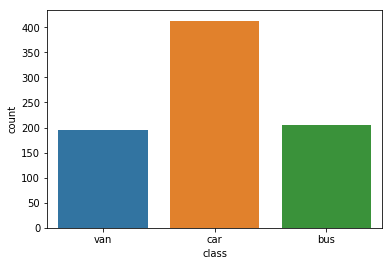

```python
sns.countplot(x='class', data = dataset2)
```

### Check for any missing values in the data

```python
dataset2.isnull().sum()
```

```
compactness                    0
circularity                    0
distance_circularity           0
radius_ratio                   0
pr.axis_aspect_ratio           0
max.length_aspect_ratio        0
scatter_ratio                  0
elongatedness                  0
pr.axis_rectangularity         0
max.length_rectangularity      0
scaled_variance                0
scaled_variance.1              0
scaled_radius_of_gyration      0
scaled_radius_of_gyration.1    0
skewness_about                 0
skewness_about.1               0
skewness_about.2               0
hollows_ratio                  0
class                          0
dtype: int64
```

### 3. Standardize the data

```python
from scipy.stats import zscore
dataset3 = dataset2.drop('class',axis=1)
zscore(dataset3)
```

```
array([[ 0.16323063,  0.52040788,  0.06066872, ...,  0.37128716,
        -0.3218087 ,  0.17183708],
       [-0.32287376, -0.61912319,  0.12406675, ...,  0.14710858,
         0.00340009,  0.44231829],
       [ 1.2569655 ,  0.84598818,  1.51882349, ..., -0.41333788,
        -0.1592043 ,  0.03659647],
       ...,
       [ 1.5000177 ,  1.49714879,  1.20183332, ..., -0.97378433,
        -0.3218087 ,  0.7127995 ],
       [-0.93050425, -1.43307395, -0.25632145, ...,  1.38009078,
         0.16600449, -0.09864413],
       [-1.05203035, -1.43307395, -1.01709784, ...,  0.59546574,
        -0.4844131 , -0.77484716]])
```

Since the dimensions of the data are not really known to us, it would be wise to standardize the data using z scores before we go for any clustering methods. You can use zscore function to do this

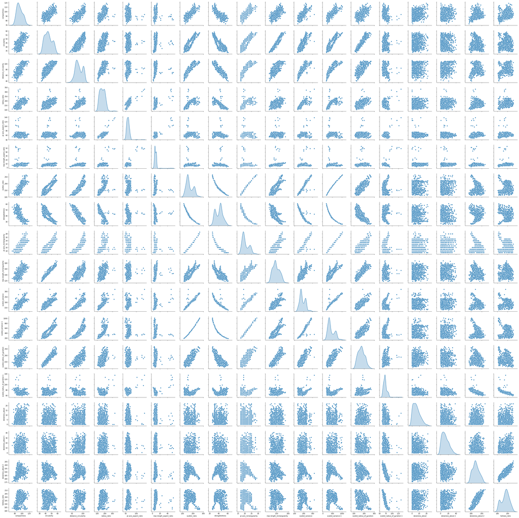

```python
sns.pairplot(dataset2,diag_kind = 'kde')
```

### 4. Assign a dummy array called distortion

```python
distortion = []
```

You can later use this array to plot the elbow plot

```python
from sklearn.cluster import KMeans
from scipy.spatial import distance
```

### 5. Calculating distortion - C distance

```python
cluster_error = []
cluster_silh_score = []
cluster_range = range(1,10)
```

```python
for num_cluster in cluster_range:
    clusters= KMeans(num_cluster,n_init=5)
    clusters.fit(dataset3)
    labels = clusters.labels_
    centroids = clusters.cluster_centers_   #The value that is arrived from the Kmeans Algorithm
    cluster_error.append(clusters.inertia_)   # The error or inertia values are stored on the cluster _errors array
    distortion.append(sum(np.min(distance.cdist(dataset3,clusters.cluster_centers_,'euclidean'),axis=1))/dataset3.shape[0])


print(len(cluster_range))
print(len(cluster_error))
```

```
9
9
```

```python
clusters_dataframe = pd.DataFrame({"num_clusters":cluster_range,"clusters_errors":cluster_error})
clusters_dataframe
```

|  | num_clusters | clusters_errors |
| --- | --- | --- |
| 0 | 1 | 2.917617e+07 |
| 1 | 2 | 6.905477e+06 |
| 2 | 3 | 4.610991e+06 |
| 3 | 4 | 3.333244e+06 |
| 4 | 5 | 2.288297e+06 |
| 5 | 6 | 1.823916e+06 |
| 6 | 7 | 1.601449e+06 |
| 7 | 8 | 1.442048e+06 |
| 8 | 9 | 1.308868e+06 |

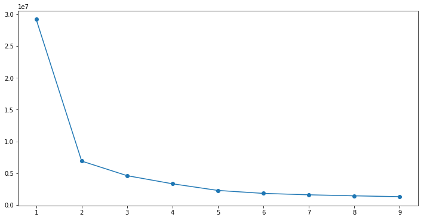

```python
plt.figure(figsize = (12,6))
plt.plot(clusters_dataframe.num_clusters,clusters_dataframe.clusters_errors,marker='o')
```

### 6. Plotting Elbow/ Scree Plot

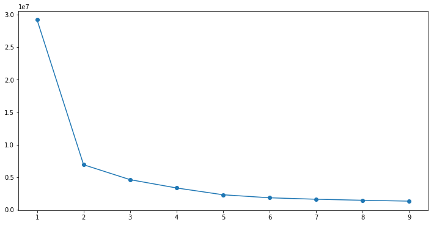

```python
plt.figure(figsize = (12,6))
plt.plot(clusters_dataframe.num_clusters,clusters_dataframe.clusters_errors,marker='o')
```

Use Matplotlib to plot the scree plot - Note: Scree plot plots distortion vs the no of clusters

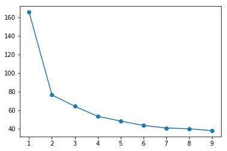

```python
plt.plot(clusters_dataframe.num_clusters,distortion,marker='o')
```

### Find out the optimal value of K

```python
kmeans = KMeans(n_clusters= 3)
```

```python
kmeans = kmeans.fit(dataset3)
```

```python
labels = kmeans.predict(dataset3)
```

### Using optimal value of K - Cluster the data.

Note: Since the data has more than 2 dimension we cannot visualize the data. As an alternative, we can observe the centroids and note how they are distributed across different dimensions

```python
centroid = kmeans.cluster_centers_
```

```python
print(centroid)
```

```
[[ 88.32403433  41.20600858  71.18240343 146.61587983  60.46566524
    7.96351931 144.26824034  46.75751073  18.70171674 140.2639485
  166.01072961 310.31330472 157.11802575  73.39914163   6.07939914
   10.91201717 187.91630901 193.98283262]
 [104.15920398  53.0199005  102.81094527 202.02985075  62.10447761
    9.82089552 217.23383085  30.70646766  24.40298507 166.37313433
  230.07462687 700.87064677 213.72636816  72.45771144   7.30845771
   15.90547264 188.         196.43283582]
 [ 96.21917808  44.97260274  88.11643836 195.52054795  65.5
    8.94520548 179.10273973  36.73287671  21.19178082 146.79452055
  202.3630137  485.78082192 174.59589041  69.13013699   5.90410959
   13.92465753 193.71917808 200.33561644]]
```

You can use kmeans.cluster*centers* function to pull the centroid information from the instance

```python
dataset3
```

|  | compactness | circularity | distance_circularity | radius_ratio | pr.axis_aspect_ratio | max.length_aspect_ratio | scatter_ratio | elongatedness | pr.axis_rectangularity | max.length_rectangularity | scaled_variance | scaled_variance.1 | scaled_radius_of_gyration | scaled_radius_of_gyration.1 | skewness_about | skewness_about.1 | skewness_about.2 | hollows_ratio |
| --- | --- | --- | --- | --- | --- | --- | --- | --- | --- | --- | --- | --- | --- | --- | --- | --- | --- | --- |
| 0 | 95 | 48.0 | 83.0 | 178.0 | 72.0 | 10 | 162.0 | 42.0 | 20.0 | 159 | 176.0 | 379.0 | 184.0 | 70.0 | 6.0 | 16.0 | 187.0 | 197 |
| 1 | 91 | 41.0 | 84.0 | 141.0 | 57.0 | 9 | 149.0 | 45.0 | 19.0 | 143 | 170.0 | 330.0 | 158.0 | 72.0 | 9.0 | 14.0 | 189.0 | 199 |
| 2 | 104 | 50.0 | 106.0 | 209.0 | 66.0 | 10 | 207.0 | 32.0 | 23.0 | 158 | 223.0 | 635.0 | 220.0 | 73.0 | 14.0 | 9.0 | 188.0 | 196 |
| 3 | 93 | 41.0 | 82.0 | 159.0 | 63.0 | 9 | 144.0 | 46.0 | 19.0 | 143 | 160.0 | 309.0 | 127.0 | 63.0 | 6.0 | 10.0 | 199.0 | 207 |
| 4 | 85 | 44.0 | 70.0 | 205.0 | 103.0 | 52 | 149.0 | 45.0 | 19.0 | 144 | 241.0 | 325.0 | 188.0 | 127.0 | 9.0 | 11.0 | 180.0 | 183 |
| 6 | 97 | 43.0 | 73.0 | 173.0 | 65.0 | 6 | 153.0 | 42.0 | 19.0 | 143 | 176.0 | 361.0 | 172.0 | 66.0 | 13.0 | 1.0 | 200.0 | 204 |
| 7 | 90 | 43.0 | 66.0 | 157.0 | 65.0 | 9 | 137.0 | 48.0 | 18.0 | 146 | 162.0 | 281.0 | 164.0 | 67.0 | 3.0 | 3.0 | 193.0 | 202 |
| 8 | 86 | 34.0 | 62.0 | 140.0 | 61.0 | 7 | 122.0 | 54.0 | 17.0 | 127 | 141.0 | 223.0 | 112.0 | 64.0 | 2.0 | 14.0 | 200.0 | 208 |
| 10 | 86 | 36.0 | 70.0 | 143.0 | 61.0 | 9 | 133.0 | 50.0 | 18.0 | 130 | 153.0 | 266.0 | 127.0 | 66.0 | 2.0 | 10.0 | 194.0 | 202 |
| 11 | 90 | 34.0 | 66.0 | 136.0 | 55.0 | 6 | 123.0 | 54.0 | 17.0 | 118 | 148.0 | 224.0 | 118.0 | 65.0 | 5.0 | 26.0 | 196.0 | 202 |
| 12 | 88 | 46.0 | 74.0 | 171.0 | 68.0 | 6 | 152.0 | 43.0 | 19.0 | 148 | 180.0 | 349.0 | 192.0 | 71.0 | 5.0 | 11.0 | 189.0 | 195 |
| 13 | 89 | 42.0 | 85.0 | 144.0 | 58.0 | 10 | 152.0 | 44.0 | 19.0 | 144 | 173.0 | 345.0 | 161.0 | 72.0 | 8.0 | 13.0 | 187.0 | 197 |
| 14 | 94 | 49.0 | 79.0 | 203.0 | 71.0 | 5 | 174.0 | 37.0 | 21.0 | 154 | 196.0 | 465.0 | 206.0 | 71.0 | 6.0 | 2.0 | 197.0 | 199 |
| 15 | 96 | 55.0 | 103.0 | 201.0 | 65.0 | 9 | 204.0 | 32.0 | 23.0 | 166 | 227.0 | 624.0 | 246.0 | 74.0 | 6.0 | 2.0 | 186.0 | 194 |
| 16 | 89 | 36.0 | 51.0 | 109.0 | 52.0 | 6 | 118.0 | 57.0 | 17.0 | 129 | 137.0 | 206.0 | 125.0 | 80.0 | 2.0 | 14.0 | 181.0 | 185 |
| 17 | 99 | 41.0 | 77.0 | 197.0 | 69.0 | 6 | 177.0 | 36.0 | 21.0 | 139 | 202.0 | 485.0 | 151.0 | 72.0 | 4.0 | 10.0 | 198.0 | 199 |
| 18 | 104 | 54.0 | 100.0 | 186.0 | 61.0 | 10 | 216.0 | 31.0 | 24.0 | 173 | 225.0 | 686.0 | 220.0 | 74.0 | 5.0 | 11.0 | 185.0 | 195 |
| 20 | 84 | 47.0 | 75.0 | 153.0 | 64.0 | 6 | 154.0 | 43.0 | 19.0 | 145 | 175.0 | 354.0 | 184.0 | 75.0 | 0.0 | 3.0 | 185.0 | 192 |
| 21 | 84 | 37.0 | 53.0 | 121.0 | 59.0 | 5 | 123.0 | 55.0 | 17.0 | 125 | 141.0 | 221.0 | 133.0 | 82.0 | 7.0 | 1.0 | 179.0 | 183 |
| 22 | 94 | 43.0 | 64.0 | 173.0 | 69.0 | 7 | 150.0 | 43.0 | 19.0 | 142 | 169.0 | 344.0 | 177.0 | 68.0 | 9.0 | 1.0 | 199.0 | 206 |
| 23 | 87 | 39.0 | 70.0 | 148.0 | 61.0 | 7 | 143.0 | 46.0 | 18.0 | 136 | 164.0 | 307.0 | 141.0 | 69.0 | 1.0 | 2.0 | 192.0 | 199 |
| 24 | 99 | 53.0 | 105.0 | 219.0 | 66.0 | 11 | 204.0 | 32.0 | 23.0 | 165 | 221.0 | 623.0 | 224.0 | 68.0 | 0.0 | 6.0 | 191.0 | 201 |
| 25 | 85 | 45.0 | 80.0 | 154.0 | 64.0 | 9 | 147.0 | 45.0 | 19.0 | 148 | 169.0 | 324.0 | 174.0 | 71.0 | 1.0 | 4.0 | 188.0 | 199 |
| 26 | 83 | 36.0 | 54.0 | 119.0 | 57.0 | 6 | 128.0 | 53.0 | 18.0 | 125 | 143.0 | 238.0 | 139.0 | 82.0 | 6.0 | 3.0 | 179.0 | 183 |
| 27 | 107 | 54.0 | 98.0 | 203.0 | 65.0 | 11 | 218.0 | 31.0 | 25.0 | 167 | 229.0 | 696.0 | 216.0 | 72.0 | 1.0 | 28.0 | 187.0 | 199 |
| 28 | 102 | 45.0 | 85.0 | 193.0 | 64.0 | 6 | 192.0 | 33.0 | 22.0 | 146 | 217.0 | 570.0 | 163.0 | 76.0 | 6.0 | 7.0 | 195.0 | 193 |
| 29 | 80 | 38.0 | 63.0 | 129.0 | 55.0 | 7 | 146.0 | 46.0 | 19.0 | 130 | 168.0 | 314.0 | 158.0 | 83.0 | 9.0 | 20.0 | 180.0 | 185 |
| 30 | 89 | 43.0 | 85.0 | 160.0 | 64.0 | 11 | 155.0 | 43.0 | 19.0 | 151 | 173.0 | 356.0 | 174.0 | 72.0 | 5.0 | 9.0 | 185.0 | 196 |
| 31 | 88 | 42.0 | 77.0 | 151.0 | 58.0 | 8 | 140.0 | 47.0 | 18.0 | 142 | 165.0 | 293.0 | 158.0 | 64.0 | 10.0 | 11.0 | 198.0 | 205 |
| 32 | 93 | 35.0 | 66.0 | 154.0 | 59.0 | 6 | 142.0 | 46.0 | 18.0 | 128 | 162.0 | 304.0 | 120.0 | 64.0 | 5.0 | 13.0 | 197.0 | 202 |
| ... | ... | ... | ... | ... | ... | ... | ... | ... | ... | ... | ... | ... | ... | ... | ... | ... | ... | ... |
| 816 | 90 | 48.0 | 85.0 | 157.0 | 64.0 | 11 | 161.0 | 43.0 | 20.0 | 167 | 175.0 | 375.0 | 186.0 | 74.0 | 3.0 | 16.0 | 185.0 | 195 |
| 817 | 104 | 53.0 | 108.0 | 204.0 | 64.0 | 11 | 220.0 | 31.0 | 25.0 | 172 | 226.0 | 707.0 | 203.0 | 71.0 | 14.0 | 30.0 | 189.0 | 203 |
| 818 | 95 | 43.0 | 96.0 | 202.0 | 65.0 | 10 | 189.0 | 35.0 | 22.0 | 143 | 217.0 | 534.0 | 166.0 | 71.0 | 6.0 | 27.0 | 190.0 | 197 |
| 819 | 93 | 42.0 | 98.0 | 192.0 | 63.0 | 9 | 185.0 | 36.0 | 22.0 | 138 | 206.0 | 508.0 | 173.0 | 70.0 | 10.0 | 21.0 | 189.0 | 197 |
| 820 | 87 | 38.0 | 71.0 | 123.0 | 53.0 | 8 | 137.0 | 49.0 | 18.0 | 127 | 158.0 | 277.0 | 145.0 | 75.0 | 0.0 | 9.0 | 181.0 | 186 |
| 821 | 104 | 56.0 | 96.0 | 231.0 | 74.0 | 11 | 220.0 | 30.0 | 25.0 | 172 | 223.0 | 713.0 | 218.0 | 73.0 | 6.0 | 16.0 | 186.0 | 195 |
| 822 | 95 | 41.0 | 82.0 | 170.0 | 65.0 | 9 | 145.0 | 46.0 | 19.0 | 145 | 163.0 | 314.0 | 140.0 | 64.0 | 4.0 | 8.0 | 199.0 | 207 |
| 823 | 105 | 54.0 | 105.0 | 213.0 | 67.0 | 10 | 200.0 | 33.0 | 23.0 | 163 | 214.0 | 597.0 | 214.0 | 68.0 | 10.0 | 20.0 | 190.0 | 198 |
| 824 | 106 | 55.0 | 96.0 | 196.0 | 60.0 | 12 | 221.0 | 30.0 | 25.0 | 173 | 225.0 | 717.0 | 214.0 | 72.0 | 9.0 | 13.0 | 186.0 | 196 |
| 825 | 86 | 39.0 | 84.0 | 149.0 | 57.0 | 8 | 156.0 | 43.0 | 20.0 | 133 | 185.0 | 358.0 | 157.0 | 74.0 | 0.0 | 23.0 | 183.0 | 190 |
| 826 | 95 | 49.0 | 92.0 | 193.0 | 62.0 | 10 | 178.0 | 37.0 | 21.0 | 154 | 200.0 | 478.0 | 171.0 | 64.0 | 2.0 | 0.0 | 198.0 | 206 |
| 827 | 99 | 57.0 | 100.0 | 177.0 | 54.0 | 13 | 224.0 | 30.0 | 25.0 | 188 | 223.0 | 726.0 | 213.0 | 72.0 | 4.0 | 7.0 | 185.0 | 198 |
| 828 | 89 | 42.0 | 66.0 | 125.0 | 53.0 | 7 | 131.0 | 51.0 | 18.0 | 144 | 162.0 | 254.0 | 162.0 | 73.0 | 10.0 | 17.0 | 188.0 | 191 |
| 829 | 95 | 49.0 | 82.0 | 139.0 | 56.0 | 11 | 159.0 | 43.0 | 20.0 | 162 | 173.0 | 365.0 | 185.0 | 75.0 | 7.0 | 10.0 | 182.0 | 191 |
| 830 | 97 | 37.0 | 70.0 | 173.0 | 66.0 | 7 | 151.0 | 43.0 | 19.0 | 129 | 167.0 | 346.0 | 119.0 | 65.0 | 0.0 | 16.0 | 201.0 | 208 |
| 831 | 100 | 47.0 | 70.0 | 185.0 | 70.0 | 7 | 162.0 | 40.0 | 20.0 | 153 | 179.0 | 406.0 | 172.0 | 68.0 | 9.0 | 6.0 | 200.0 | 205 |
| 832 | 108 | 49.0 | 109.0 | 204.0 | 61.0 | 11 | 212.0 | 31.0 | 24.0 | 159 | 229.0 | 665.0 | 215.0 | 71.0 | 16.0 | 11.0 | 190.0 | 199 |
| 833 | 92 | 46.0 | 83.0 | 154.0 | 56.0 | 6 | 160.0 | 41.0 | 20.0 | 148 | 185.0 | 382.0 | 184.0 | 71.0 | 10.0 | 5.0 | 186.0 | 191 |
| 834 | 82 | 36.0 | 51.0 | 114.0 | 53.0 | 4 | 135.0 | 50.0 | 18.0 | 126 | 150.0 | 268.0 | 144.0 | 86.0 | 15.0 | 4.0 | 181.0 | 182 |
| 835 | 111 | 58.0 | 105.0 | 183.0 | 51.0 | 6 | 265.0 | 26.0 | 29.0 | 174 | 285.0 | 1018.0 | 255.0 | 85.0 | 4.0 | 8.0 | 181.0 | 183 |
| 836 | 87 | 45.0 | 66.0 | 139.0 | 58.0 | 8 | 140.0 | 47.0 | 18.0 | 148 | 168.0 | 294.0 | 175.0 | 73.0 | 3.0 | 12.0 | 188.0 | 196 |
| 837 | 94 | 46.0 | 77.0 | 169.0 | 60.0 | 8 | 158.0 | 42.0 | 20.0 | 148 | 181.0 | 373.0 | 181.0 | 67.0 | 12.0 | 2.0 | 193.0 | 199 |
| 838 | 95 | 43.0 | 76.0 | 142.0 | 57.0 | 10 | 151.0 | 44.0 | 19.0 | 149 | 173.0 | 339.0 | 159.0 | 71.0 | 2.0 | 23.0 | 187.0 | 200 |
| 839 | 90 | 44.0 | 72.0 | 157.0 | 64.0 | 8 | 137.0 | 48.0 | 18.0 | 144 | 159.0 | 283.0 | 171.0 | 65.0 | 9.0 | 4.0 | 196.0 | 203 |
| 840 | 93 | 34.0 | 66.0 | 140.0 | 56.0 | 7 | 130.0 | 51.0 | 18.0 | 120 | 151.0 | 251.0 | 114.0 | 62.0 | 5.0 | 29.0 | 201.0 | 207 |
| 841 | 93 | 39.0 | 87.0 | 183.0 | 64.0 | 8 | 169.0 | 40.0 | 20.0 | 134 | 200.0 | 422.0 | 149.0 | 72.0 | 7.0 | 25.0 | 188.0 | 195 |
| 842 | 89 | 46.0 | 84.0 | 163.0 | 66.0 | 11 | 159.0 | 43.0 | 20.0 | 159 | 173.0 | 368.0 | 176.0 | 72.0 | 1.0 | 20.0 | 186.0 | 197 |
| 843 | 106 | 54.0 | 101.0 | 222.0 | 67.0 | 12 | 222.0 | 30.0 | 25.0 | 173 | 228.0 | 721.0 | 200.0 | 70.0 | 3.0 | 4.0 | 187.0 | 201 |
| 844 | 86 | 36.0 | 78.0 | 146.0 | 58.0 | 7 | 135.0 | 50.0 | 18.0 | 124 | 155.0 | 270.0 | 148.0 | 66.0 | 0.0 | 25.0 | 190.0 | 195 |
| 845 | 85 | 36.0 | 66.0 | 123.0 | 55.0 | 5 | 120.0 | 56.0 | 17.0 | 128 | 140.0 | 212.0 | 131.0 | 73.0 | 1.0 | 18.0 | 186.0 | 190 |

813 rows × 18 columns

### 7. Store the centroids in a dataframe with column names from the original dataset given

```python
cluster_dataframe = pd.DataFrame(centroid,columns = list(dataset3))
```

Hint: Use pd.Dataframe function

```python
cluster_dataframe
```

|  | compactness | circularity | distance_circularity | radius_ratio | pr.axis_aspect_ratio | max.length_aspect_ratio | scatter_ratio | elongatedness | pr.axis_rectangularity | max.length_rectangularity | scaled_variance | scaled_variance.1 | scaled_radius_of_gyration | scaled_radius_of_gyration.1 | skewness_about | skewness_about.1 | skewness_about.2 | hollows_ratio |
| --- | --- | --- | --- | --- | --- | --- | --- | --- | --- | --- | --- | --- | --- | --- | --- | --- | --- | --- |
| 0 | 88.324034 | 41.206009 | 71.182403 | 146.615880 | 60.465665 | 7.963519 | 144.268240 | 46.757511 | 18.701717 | 140.263948 | 166.010730 | 310.313305 | 157.118026 | 73.399142 | 6.079399 | 10.912017 | 187.916309 | 193.982833 |
| 1 | 104.159204 | 53.019900 | 102.810945 | 202.029851 | 62.104478 | 9.820896 | 217.233831 | 30.706468 | 24.402985 | 166.373134 | 230.074627 | 700.870647 | 213.726368 | 72.457711 | 7.308458 | 15.905473 | 188.000000 | 196.432836 |
| 2 | 96.219178 | 44.972603 | 88.116438 | 195.520548 | 65.500000 | 8.945205 | 179.102740 | 36.732877 | 21.191781 | 146.794521 | 202.363014 | 485.780822 | 174.595890 | 69.130137 | 5.904110 | 13.924658 | 193.719178 | 200.335616 |

## Hierarchical Clustering

### 8. Variable creation

For Hierarchical clustering, we will create datasets using multivariate normal distribution to visually observe how the clusters are formed at the end

```python
a = np.random.multivariate_normal([10, 0], [[3, 1], [1, 4]], size=[100,])
b = np.random.multivariate_normal([0, 20], [[3, 1], [1, 4]], size=[50,])
c = np.random.multivariate_normal([10, 20], [[3, 1], [1, 4]], size=[100,])
```

### 9. Combine all three arrays a,b,c into a dataframe

```python
dataframe6= np.concatenate([a,b,c])
```

```python
dataframe7=pd.DataFrame(dataframe6)
```

```python
type(dataframe7)
```

```
pandas.core.frame.DataFrame
```

### 10. Use scatter matrix to print all the 3 distributions

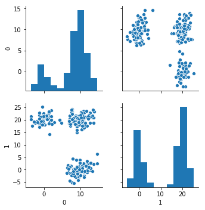

```python
sns.pairplot(dataframe7)
```

### 11. Find out the linkage matrix

```python
from scipy.cluster.hierarchy import cophenet, dendrogram, linkage
from scipy.spatial.distance import pdist
```

Use ward as linkage metric and distance as Eucledian

```python
Z = linkage(dataframe7, 'ward')
c, coph_dists = cophenet(Z , pdist(dataframe7))
c
```

```
0.9589504381699895
```

```python
Z.shape
```

```
(249, 4)
```

```python
Z[1:20]
```

```
array([[2.04000000e+02, 2.19000000e+02, 4.28687950e-02, 2.00000000e+00],
       [5.20000000e+01, 8.50000000e+01, 4.32544924e-02, 2.00000000e+00],
       [1.61000000e+02, 2.33000000e+02, 4.34725918e-02, 2.00000000e+00],
       [1.71000000e+02, 2.07000000e+02, 4.46465524e-02, 2.00000000e+00],
       [6.40000000e+01, 7.70000000e+01, 4.91180806e-02, 2.00000000e+00],
       [2.11000000e+02, 2.41000000e+02, 5.56393823e-02, 2.00000000e+00],
       [6.70000000e+01, 7.10000000e+01, 6.07430282e-02, 2.00000000e+00],
       [7.00000000e+00, 4.30000000e+01, 7.85286496e-02, 2.00000000e+00],
       [1.86000000e+02, 1.92000000e+02, 9.11370555e-02, 2.00000000e+00],
       [1.08000000e+02, 1.42000000e+02, 1.03825589e-01, 2.00000000e+00],
       [1.95000000e+02, 2.27000000e+02, 1.08077603e-01, 2.00000000e+00],
       [1.99000000e+02, 2.22000000e+02, 1.15898408e-01, 2.00000000e+00],
       [4.20000000e+01, 4.80000000e+01, 1.16486782e-01, 2.00000000e+00],
       [1.74000000e+02, 2.31000000e+02, 1.25841573e-01, 2.00000000e+00],
       [7.00000000e+01, 2.52000000e+02, 1.30837879e-01, 3.00000000e+00],
       [2.80000000e+01, 3.70000000e+01, 1.39030477e-01, 2.00000000e+00],
       [1.28000000e+02, 1.48000000e+02, 1.39553361e-01, 2.00000000e+00],
       [1.87000000e+02, 2.39000000e+02, 1.39838273e-01, 2.00000000e+00],
       [3.90000000e+01, 6.50000000e+01, 1.53518771e-01, 2.00000000e+00]])
```

### 12. Plot the dendrogram for the consolidated dataframe

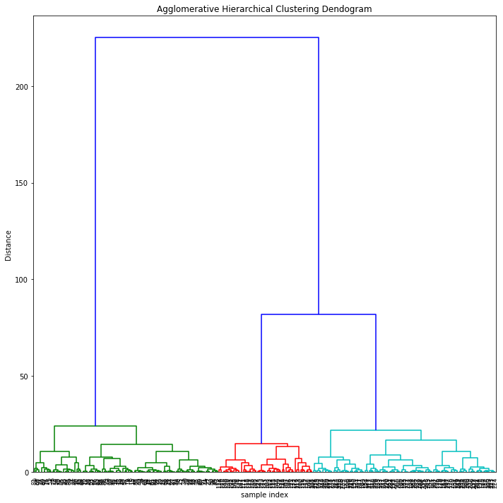

```python
plt.figure(figsize=(10, 10))
plt.title('Agglomerative Hierarchical Clustering Dendogram')
plt.xlabel('sample index')
plt.ylabel('Distance')
dendrogram(Z, leaf_rotation=90.,color_threshold = 30, leaf_font_size=8. )
plt.tight_layout()
```

### 13. Recreate the dendrogram for last 12 merged clusters

```
{'icoord': [[5.0, 5.0, 15.0, 15.0],
  [35.0, 35.0, 45.0, 45.0],
  [25.0, 25.0, 40.0, 40.0],
  [10.0, 10.0, 32.5, 32.5],
  [65.0, 65.0, 75.0, 75.0],
  [55.0, 55.0, 70.0, 70.0],
  [105.0, 105.0, 115.0, 115.0],
  [95.0, 95.0, 110.0, 110.0],
  [85.0, 85.0, 102.5, 102.5],
  [62.5, 62.5, 93.75, 93.75],
  [21.25, 21.25, 78.125, 78.125]],
 'dcoord': [[0.0, 10.951419253576217, 10.951419253576217, 0.0],
  [0.0, 10.842988642879074, 10.842988642879074, 0.0],
  [0.0, 14.472643712797515, 14.472643712797515, 10.842988642879074],
  [10.951419253576217,
   24.11319691653668,
   24.11319691653668,
   14.472643712797515],
  [0.0, 13.235656094969556, 13.235656094969556, 0.0],
  [0.0, 14.812553911528337, 14.812553911528337, 13.235656094969556],
  [0.0, 10.663993285594453, 10.663993285594453, 0.0],
  [0.0, 16.44682206257147, 16.44682206257147, 10.663993285594453],
  [0.0, 21.880186472993287, 21.880186472993287, 16.44682206257147],
  [14.812553911528337,
   81.91690346594092,
   81.91690346594092,
   21.880186472993287],
  [24.11319691653668,
   225.17341401638996,
   225.17341401638996,
   81.91690346594092]],
 'ivl': ['(10)',
  '(16)',
  '(28)',
  '(23)',
  '(23)',
  '(21)',
  '(20)',
  '(10)',
  '(28)',
  '(37)',
  '(14)',
  '(20)'],
 'leaves': [472, 486, 484, 474, 476, 479, 480, 481, 485, 487, 462, 483],
 'color_list': ['g', 'g', 'g', 'g', 'r', 'r', 'r', 'r', 'r', 'r', 'b']}
```

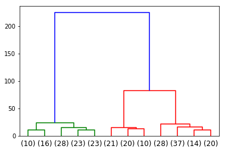

```python
dendrogram(Z, 12, truncate_mode='lastp')
```

Hint: Use truncate_mode='lastp' attribute in dendrogram function to arrive at dendrogram

### 14. From the truncated dendrogram, find out the optimal distance between clusters which u want to use an input for clustering data

```python
maxd=50
```

### 15. Using this distance measure and fcluster function to cluster the data into 3 different groups

```python
from scipy.cluster.hierarchy import fcluster
```

```python
cluster = fcluster(Z, maxd, criterion='distance')
cluster
```

```
array([1, 1, 1, 1, 1, 1, 1, 1, 1, 1, 1, 1, 1, 1, 1, 1, 1, 1, 1, 1, 1, 1,
       1, 1, 1, 1, 1, 1, 1, 1, 1, 1, 1, 1, 1, 1, 1, 1, 1, 1, 1, 1, 1, 1,
       1, 1, 1, 1, 1, 1, 1, 1, 1, 1, 1, 1, 1, 1, 1, 1, 1, 1, 1, 1, 1, 1,
       1, 1, 1, 1, 1, 1, 1, 1, 1, 1, 1, 1, 1, 1, 1, 1, 1, 1, 1, 1, 1, 1,
       1, 1, 1, 1, 1, 1, 1, 1, 1, 1, 1, 1, 2, 2, 2, 2, 2, 2, 2, 2, 2, 2,
       2, 2, 2, 2, 2, 2, 2, 2, 2, 2, 2, 2, 2, 2, 2, 2, 2, 2, 2, 2, 2, 2,
       2, 2, 2, 2, 2, 2, 2, 2, 2, 2, 2, 2, 2, 2, 2, 2, 2, 2, 3, 3, 3, 3,
       3, 3, 3, 3, 3, 3, 3, 3, 3, 3, 3, 3, 3, 3, 3, 3, 3, 3, 3, 3, 3, 3,
       3, 3, 3, 3, 3, 3, 3, 3, 3, 3, 3, 3, 3, 3, 3, 3, 3, 3, 3, 3, 3, 3,
       3, 3, 3, 3, 3, 3, 3, 3, 3, 3, 3, 3, 3, 3, 3, 2, 3, 3, 3, 3, 3, 3,
       3, 3, 3, 3, 3, 3, 3, 3, 3, 3, 3, 3, 3, 3, 3, 3, 3, 3, 3, 3, 3, 3,
       3, 3, 3, 3, 3, 3, 3, 3], dtype=int32)
```

### Use matplotlib to visually observe the clusters in 2D space

```python
dataframe7.columns =['a','b']
```

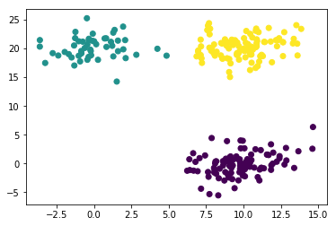

```python
plt.scatter(dataframe7['a'], dataframe7['b'], c = cluster)
```